# Twitter zzh-gj-jz association

26 May, 2022

In this analysis I will first extract tweets mentioning “#zhangzhehan”, “#gongjun” or “#junzhe” and then check the overlap between accounts tweeting about these topics. After playing around a bit I decided to use only hashtags instead of full names to focus on dedicated tweets instead of casual mentions.

I will then plot the accounts with the most tweets about these topics.

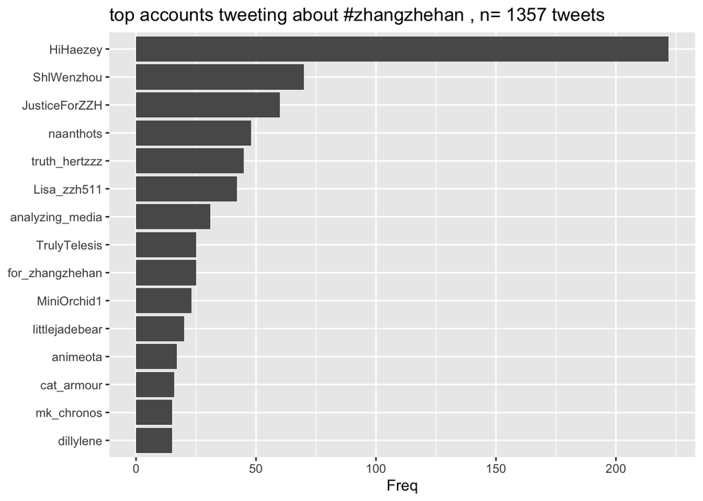

```r
###extract tweets

tweets_extract_plot<-function(words,title){
  tweets<-search_tweets2(words,n = 6000,lang = "en",include_rts = FALSE)
  n_tweets<-nrow(tweets)
  stats<-paste(title,collapse=" ")
  stats<-paste(stats,", n=",n_tweets,"tweets")

  plot<-table(tweets$screen_name)%>%
    as.data.frame() %>%
    arrange(desc(Freq)) %>%
    top_n(15) %>%
    mutate(Var1 = reorder(Var1, Freq)) %>%
    ggplot(aes(x = Var1, y = Freq)) +
    geom_col() +
    xlab(NULL) +
    coord_flip() +
    ggtitle(paste("top accounts tweeting about",stats))
  print(plot)
  return(tweets)
}
zzh_tweets<-tweets_extract_plot(c("#zhangzhehan"),"#zhangzhehan")
```

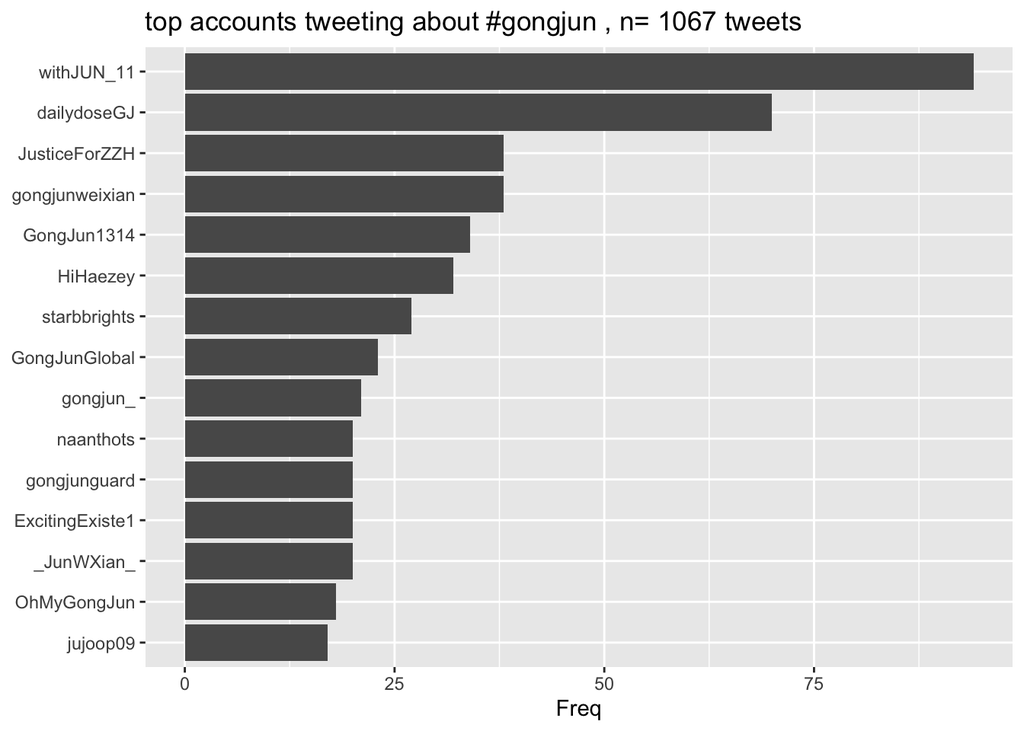

```r
gj_tweets<-tweets_extract_plot(c("#gongjun"),"#gongjun")
```

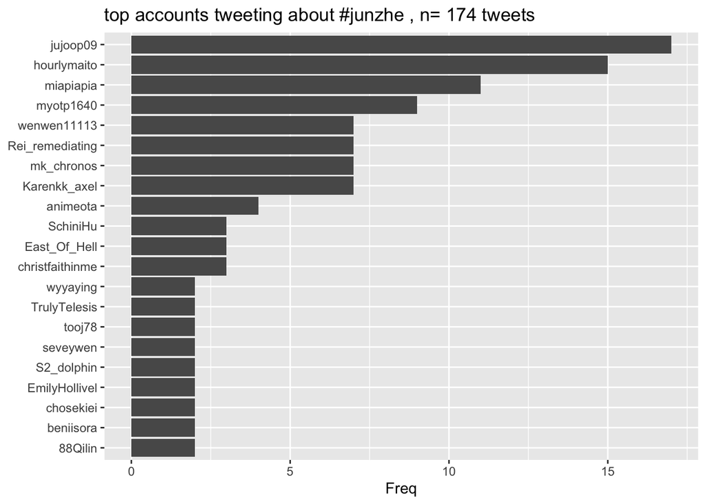

```r
jz_tweets<-tweets_extract_plot(c("#junzhe"),"#junzhe")
```

Quick info on which timespan the datasets cover and how many tweets per day

```r
#calculate rate of tweets per hour
tweet_stats<-function(data,title){
  print(paste("dataset:",title))
  print(paste("number of tweets:",nrow(data)))
  start<-data[nrow(data),]$created_at
  end<-data[1,]$created_at
  print(paste("start:",start))
  print(paste("end:",end))
  diff = end - start
  print(diff)
  #tweets per day
  tw_p_day<-round(nrow(data)/as.numeric(diff),2)
  print(paste("tweets per day:",tw_p_day))
  return(tw_p_day)
}

st_zzh<-tweet_stats(zzh_tweets,"#zhangzhehan")
```

```
## [1] "dataset: #zhangzhehan"
## [1] "number of tweets: 1357"
## [1] "start: 2022-05-17 23:46:18"
## [1] "end: 2022-05-26 06:17:10"
## Time difference of 8.271435 days
## [1] "tweets per day: 164.06"
```

```r
st_gj<-tweet_stats(gj_tweets,"#gongjun")
```

```
## [1] "dataset: #gongjun"
## [1] "number of tweets: 1067"
## [1] "start: 2022-05-18 01:39:45"
## [1] "end: 2022-05-26 06:29:00"
## Time difference of 8.200868 days
## [1] "tweets per day: 130.11"
```

```r
st_jz<-tweet_stats(jz_tweets,"#junzhe")
```

```
## [1] "dataset: #junzhe"
## [1] "number of tweets: 174"
## [1] "start: 2022-05-18 01:32:49"
## [1] "end: 2022-05-26 06:00:47"
## Time difference of 8.186088 days
## [1] "tweets per day: 21.26"
```

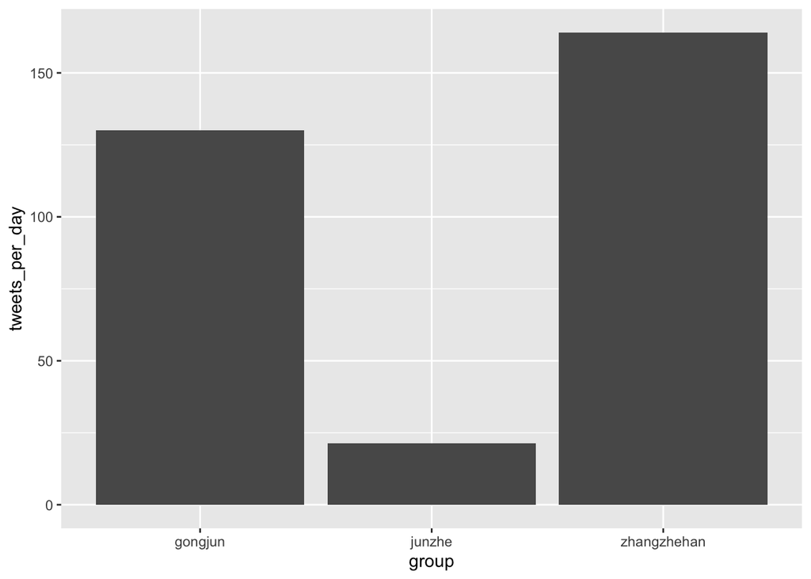

```r
bargraph<-data.frame(group=c("zhangzhehan","gongjun","junzhe"),tweets_per_day=c(st_zzh,st_gj,st_jz))

ggplot(bargraph,aes(x=group,y=tweets_per_day))+
  geom_col()
```

Next let’s make a Venn diagram to see the overlap between accounts tweeting about “Junzhe” “Zhang Zhehan” or “Gong Jun”. I have to use 2 Venn diagram packages because gplots gives me the numbers+intersections but only venneuler lets me make a beautiful diagram with proportional circle areas.

Note: This plot is not based on tweets containing the respective topics in combination. Instead it plots, e.g. how often accounts mentioning “ZZH” have also mentioned “Gong Jun”, this can be in the same or different tweets.

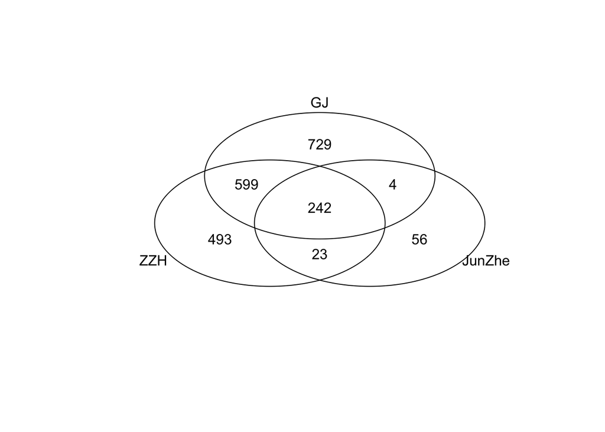

```r
###Venn diagram
library(gplots)
x <- list("ZZH" = zzh_tweets$screen_name,
          "JunZhe" = jz_tweets$screen_name,
          "GJ" = gj_tweets$screen_name)
v.table <- venn(x)
```

```r
x <- attr(v.table,"intersections")
names_venn<-sapply(seq_along(x), function(i) paste(names(x)[[i]]))
numbers_venn<-lapply(seq_along(x), function(i) length(x[[i]]))
names_venn<-str_replace(names_venn, ":", "&")
names_venn<-str_replace(names_venn, ":", "&")
numbers_venn<-as.numeric(numbers_venn)
names(numbers_venn)<-names_venn


library(venneuler)
```

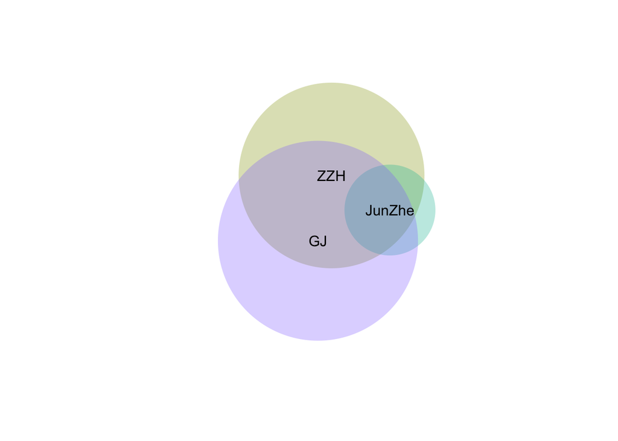

```r
v <- venneuler(numbers_venn)
plot(v)
```

Finally let’s plot the top accounts tweeting about the respective topics+combinations. In these plots, for example the “Zhang Zhehan” accounts are the accounts with the most tweets not mentioning the other topics.

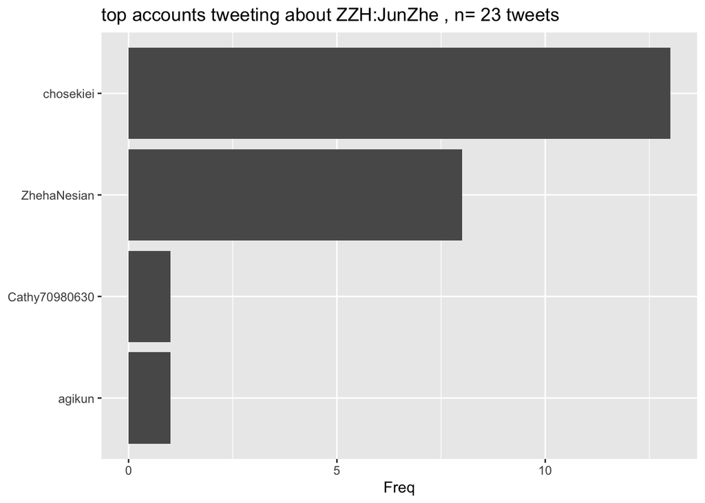

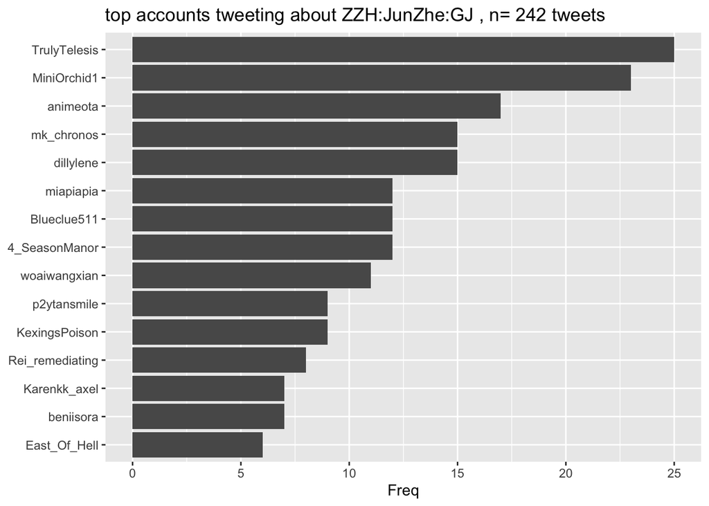

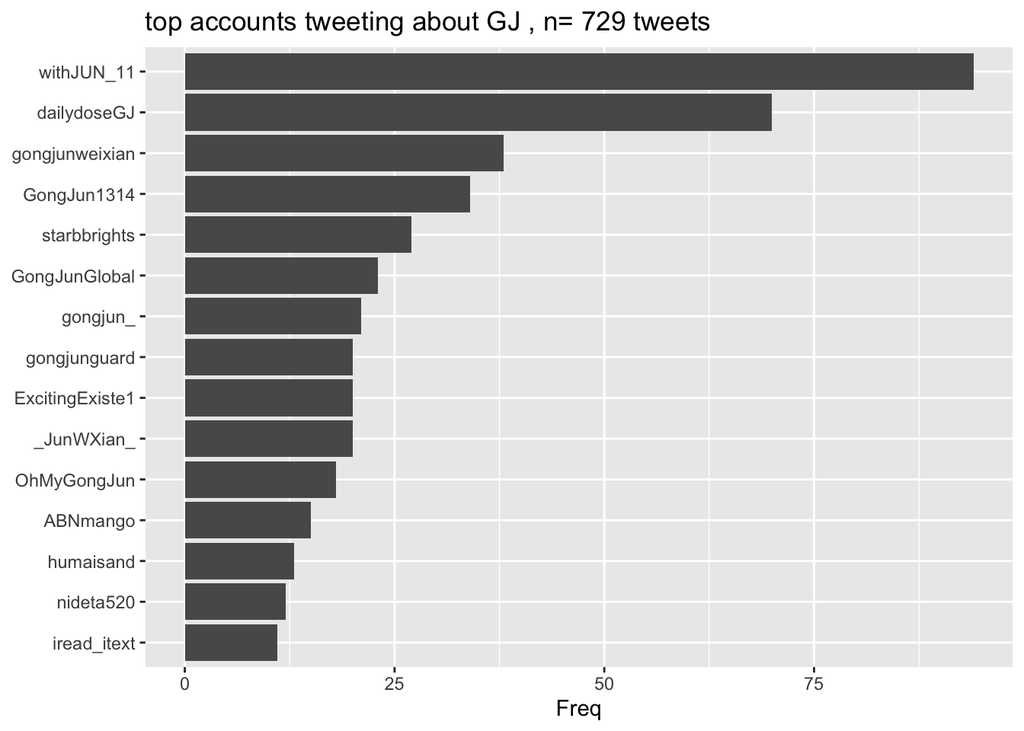

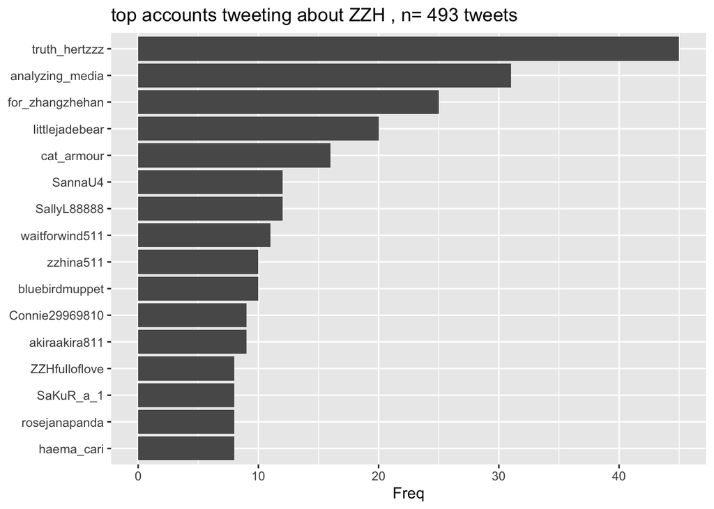

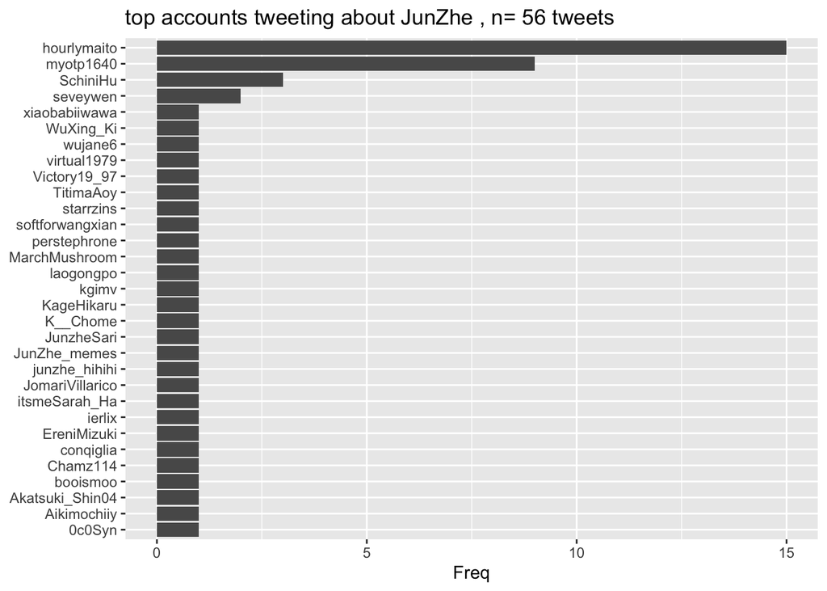

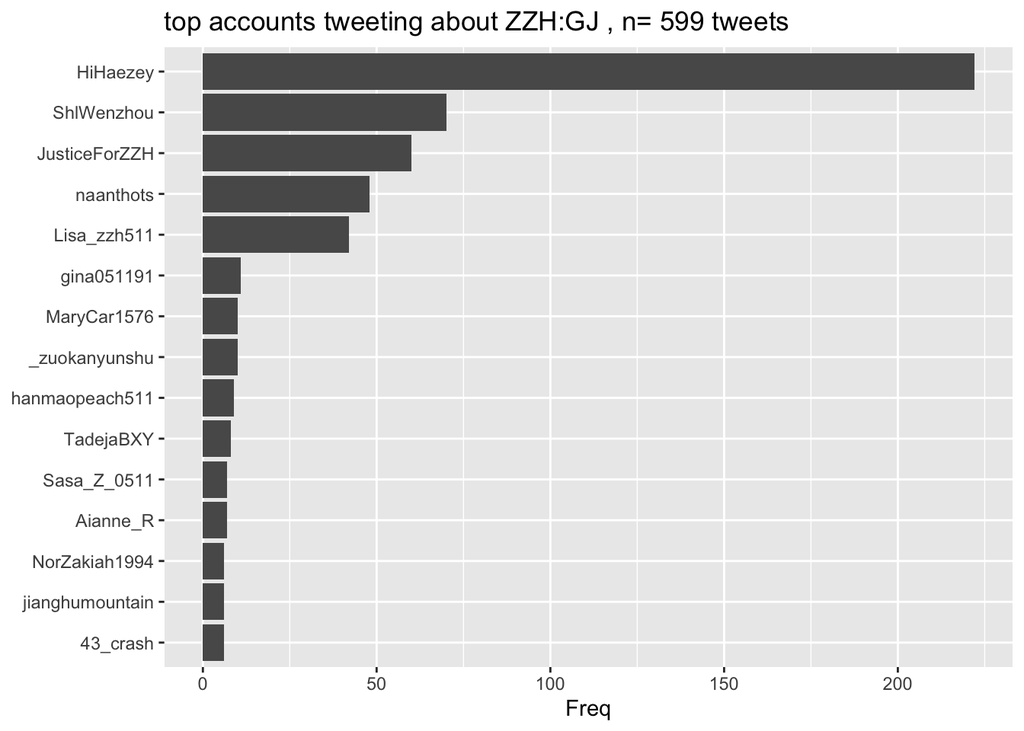

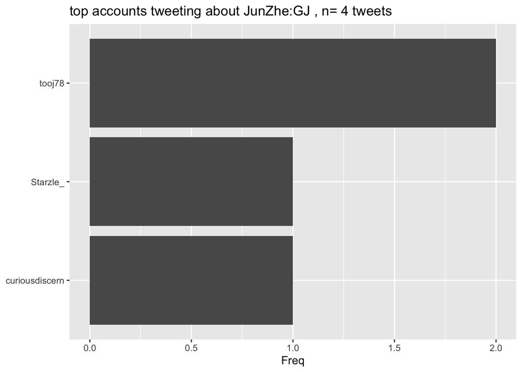

```r
###top accounts n venn diagram slices
topgraph<-function(index,data){
  n_tweets<-length(data)
  table(data)%>%
    as.data.frame() %>%
    arrange(desc(Freq)) %>%
    top_n(15) %>%
    mutate(data = reorder(data, Freq)) %>%
    ggplot(aes(x = data, y = Freq)) +
    geom_col() +
    xlab(NULL) +
    coord_flip() +
    ggtitle(paste("top accounts tweeting about",index,", n=",n_tweets,"tweets"))
}


x <- attr(v.table,"intersections")
lapply(seq_along(x), function(i) topgraph(names(x)[[i]], x[[i]]))
```